# Raptors are Effective Umbrella Species for Conservation Prioritization

Assessing the potential for raptors as umbrella species for reserve network design in Morro Bay

Conservation Planning

Author

Olivia Hemond & Madi Calbert

Published

September 22, 2024

**Background**: Raptors and other umbrella species are commonly used in designing reserve networks for biodiversity conservation. Protecting raptors helps safeguard many other species within the same ecosystem. In Morro Bay, creating reserve networks involves balancing various conservation strategies to optimize both ecological and socioeconomic factors. Designing reserve networks based on umbrella species protections can be a cost effective way to achieve conservation goals.

**Problem**: Creating a network of reserves in Morro Bay requires consideration of species richness, abundance, and distribution, the costs of land conservation, and the spatial configuration of the network. Optimizing all of these factors is computationally expensive and requires setting numerous species-specific conservation targets. We were interested in assessing the optimal reserve designs when all species (for which we had data) were taken into account, and comparing it with the optimal designs for birds of prey. The level of similarity between the two may indicate whether it is possible to use raptors as umbrella species for reserve design, reducing the need for intensive data collection across many different taxa.

**Approach**: Our approach had two components: 1) designing an optimal reserve network for all species, and 2) designing an optimal reserve network for birds of prey. The all-species reserve design included 140 species across a wide array of taxa. The birds of prey reserve design included eight (8) species of raptor: the peregrine falcon (*Falco peregrinus anatum*), Cooper’s hawk (*Accipiter cooperii*), ferruginous hawk (*Buteo regalis*), golden eagle (*Aquila chrysaetos*), merlin (*Falco columbarius*), osprey (*Pandion haliaetus*), prairie falcon (*Falco mexicanus*), and the sharp-shinned hawk (*Accipiter striatus*).

We used the *prioritizr* package in R to conduct our analyses and focused on solving Marxan problems, which optimize actions to achieve species conservation targets at the least cost. We used our data on species conservation targets, land planning unit costs, and each species’ presence in each planning unit to set up the initial Marxan problem. We wanted to calculate the optimal reserve design (optimality gap of 0%), as well as a portfolio of 100 reserve design possibilities that were within a small margin of optimal (optimality gap of 15%), so we ran two calculations with these different parameters. To solve the problems once the additional parameters were specified, we used the *gurobi* solver. In addition, for the portfolio of reserve solutions, we calculated the number of times each planning unit was selected for inclusion in the reserve, representing the frequency of selection and thus the level of priority for conservation of each unit. These analysis steps were conducted for all species first, and then repeated with the selected birds of prey species.

**Results**: As shown in Figure 1, the high priority conservation areas (dark blue) for all 140 studied species (panel A) and for the 8 raptors species (panel B) are nearly geographically identical. There are minor differences across low, moderate, and non-priority areas. Nonetheless, Figure 1 conveys that raptors have a similar optimal reserve network when compared to all studied species. When designing reserve networks based on a single optimal solution, as displayed in Figure 2, conservation priority areas across all species (panel A) and for raptors alone (panel B) are nearly identical.

**Conclusions**: Given the similarities between the optimal reserve networks for all studied species and the raptor species, our results suggest that raptors can be used as an umbrella species for Morro Bay reserve design. Utilizing raptors as an umbrella species can reduce the need for intensive data collection across many different taxa and can ultimately achieve the same conservation goals for all species. This conservation strategy will minimize costs and workload while maintaining an adequate level of protection for all studied species. This method of reserve design can create ambiguity for the protection of rare and/or threatened species (such as the California red-legged frog) and may require additional, more specialized protections for these species with unique habitat requirements. Overall, umbrella species can be a cost-effective strategy to optimize conservation efforts in Morro Bay.

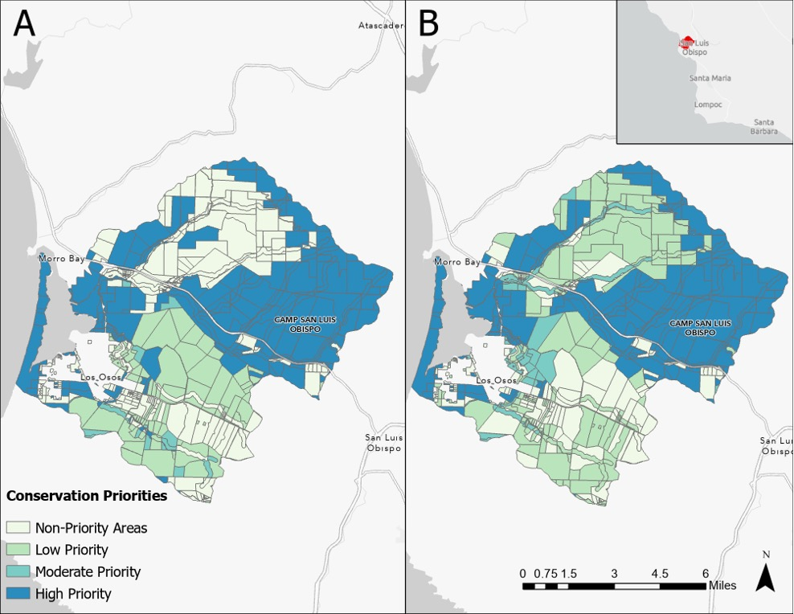

**Figure 1. Priority conservation areas in Morro Bay.** Land planning units of conservation interest for all studied species (A) and for raptors (B). Each planning unit is color-coded by conservation priority, ranging from non-priority (selected 0 times by optimization algorithm), low priority (selected once), moderate priority (selected 2 or more times), and high priority (selected every time).

[figure not shown]